# Clustering Techniques

[figure not shown]

## Introduction

**The Problem**

- In the context of unsupervised learning, the clustering problem involves **grouping a set of data points into subsets**, or "**clusters**", where points within the same cluster are more **similar** to each other than to those in other clusters.
- The goal is to identify inherent patterns or structures within the data **without any prior knowledge of group labels**.
- Clustering is widely used in various applications like market segmentation, social network analysis, organizing large data libraries, and anomaly detection in diverse fields ranging from bioinformatics to finance.
- This task distinguishes itself from other machine learning paradigms by its lack of reliance on pre-assigned labels or categories. The algorithms must discern patterns and categorizations solely based on the inherent attributes present within the data.

**Key aspects**

1. **Objective**: The primary objective is to partition the data into clusters such that the points within each cluster are more similar to each other than to points in other clusters. However, the definition of **"similarity"** can vary depending on the specific clustering algorithm and the nature of the data.
2. **Unlabeled Data**: Unlike supervised learning, where the algorithm is provided with labeled examples to learn from, in unsupervised learning, the data is unlabeled. This means that the algorithm must discover patterns or structures solely based on the inherent properties of the data itself.
3. **Algorithm Selection**: There are various clustering algorithms available, each with its own approach to defining and identifying clusters. Common algorithms include K-means, hierarchical clustering, DBSCAN (Density-Based Spatial Clustering of Applications with Noise), Gaussian Mixture Models (GMM), and more. The choice of algorithm depends on factors such as the nature of the data, the desired number of clusters, and computational considerations.
4. **Evaluation**: Evaluating the quality of clustering results can be challenging in unsupervised learning since there are no ground truth labels to compare against. However, there are several metrics and techniques, such as silhouette score, Davies-Bouldin index, and visual inspection, that can help assess the effectiveness of clustering algorithms.

**Similarity**

- A fundamental aspect of the clustering problem is the establishment of a criterion for **similarity**.
- The efficacy of clustering largely hinges on the appropriateness of the chosen similarity or distance metric (such as Euclidean or Manhattan distances). -
- These metrics are pivotal in assessing the likeness between data points, thereby guiding their aggregation into cohesive groups.

[figure not shown]

**Cluster Morphology**

- An intriguing facet of clustering is the diversity in the morphology of clusters; they can vary widely in shape, size, and distribution, presenting a significant analytical challenge, especially in datasets with complex structures or overlapping cluster boundaries.
- Another critical consideration is the determination of the optimal number of clusters, a parameter that significantly influences the outcome of the clustering process; some algorithms demand a pre-specified number of clusters, while others are capable of autonomously ascertaining this number.

[figure not shown]

**Challenges and Difficulties**

- Although the clustering problem has numerous applications, it is not without its difficulties.
- First, **the definition of a cluster is not fixed universally but varies significantly depending on the context**. Different algorithms identify clusters in different ways. For instance, some algorithms aim to find instances grouped around a central point, termed a centroid, while others look for densely populated areas, resulting in clusters of various shapes.
- Moreover, **selecting the most suitable clustering algorithm is a complex task**, heavily influenced by the characteristics of the data and the specific needs of the clustering problem.
- Additionally, clustering high-dimensional data poses particular challenges due to the '**curse of dimensionality**', where the abundance of features causes the data to be sparse, making traditional distance measures less reliable.

**Clustering is Subjective**

[figure not shown]

- Scalability is another crucial factor, especially when dealing with large datasets, necessitating algorithms that can maintain performance without a significant compromise in accuracy.
- Furthermore, the interpretation of clustering results often lacks straightforwardness and typically requires domain-specific expertise for validation and comprehension.

## Four different types of clustering methods

1. The first one is **centroid-based** clustering. Each cluster is represented by a centroid which derives clusters based on the "distance" of the data point to the centroid of the clusters. One of the most widely used centroid-based algorithms is **k-means**.
2. The second one is **connectivity-based** clustering. The clusters are defined by grouping the nearest neighbor based on distance between the data points. The idea is that nearby data points are more related than other points farther away. Two examples of this class of methods are **Hierarchical** Clustering and **Spectral** Clustering.
3. The third one is density-based clustering. Clusters here are defined by areas of concentrated density. In this Lesson we discuss the **DBSCAN** Clustering Method which belong to this class.
4. The fourth one is **distribution-based** clustering. In this method, each cluster belongs to a normal distribution. The idea is that data points are divided based on probability of belonging to the same normal distribution. The **Gaussian Mixture Model** is one of the most important example of this kind of clustering methods.

## K-Means

### Definitions

- *k*-means clustering is one of the simplest and popular unsupervised machine learning algorithms. The objective of K-means is simple: group similar data points together and discover underlying patterns.
- To achieve this objective, K-means looks for a fixed number (k) of clusters in a dataset.
- You’ll define a target number **k**, which refers to the number of centroids you need in the dataset. A centroid is the imaginary or real location representing the center of the cluster.
- Every data point is allocated to each of the clusters through reducing the in-cluster sum of squares.

In other words, the K-means algorithm identifies k number of centroids, and then allocates every data point to the **nearest** cluster, while keeping the centroids as small as possible. The ‘means’ in the K-means refers to averaging of the data; that is, finding the centroid.

**How the K-means algorithm works**

To process the learning data, the K-means algorithm starts with a first group of randomly selected centroids, which are used as the beginning points for every cluster, and then performs iterative (repetitive) calculations to optimize the positions of the centroids. It halts creating and optimizing clusters when either:

- The centroids have stabilized — there is no change in their values because the clustering has been successful.
- The defined number of iterations has been achieved.

[figure not shown]

**A Distance Measure**

For clustering we need a distance measure. The simplest distance measure is the Euclidean Distance measure:

$$ Distance = \sqrt{(x_B-x_B)^2 + (y_B - y_A)^2} $$

[figure not shown]

**Multidimensional Distance**

In general when there are $m$ features the distance between P and Q is \begin{equation} d = \sqrt{\sum\limits_{j=1}^m \left( \nu_{pj} - \nu_{qj} \right)^2} \end{equation}  
where $\nu_{pj}$ and $\nu_{qj}$ are the values of the $j-th$ feature for $P$ and $Q$

**Local Vs Global Optima**

Unfortunately, although the algorithm is guaranteed to converge, it may not converge to the right solution (i.e., it may converge to a local optimum): this depends on the centroid initialization. A possibile solution is to run the algorithm multiple times with different random initializations and keep the best solution. This is controlled by the n_init hyperparameter: by default, it is equal to 10, which means that the whole algorithm described earlier actually runs 10 times when you call `fit()`, and `Scikit-Learn` keeps the best solution.

### Example 1 - Synthetic Dataset

- Let’s see the steps on how the K-means machine learning algorithm works using the Python programming language.
- We’ll use the Scikit-learn library and some random data to illustrate a K-means clustering simple explanation.
- Let's start to code ...

**How Find the Right Number of Clusters**

- Determining the optimal number of clusters, often denoted as $k$, in K-means clustering is a crucial step in the process.
- While there's no definitive method to find the exact number of clusters, finding the right number of clusters in K-means clustering involves a combination of statistical techniques, domain expertise, and subjective judgment.
- It's essential to consider various methods and validate the results to ensure that the chosen number of clusters accurately captures the underlying patterns in the data.

**Inertia or Within Cluster Sum of Squares (WCSS)**

- A measure of the performance of the algorithm is the within cluster sum of squares also known as **inertia**;
- For any given k the objective is to minimize inertia:

\begin{equation} Inertia = \sum\limits_{i=1}^n d_i^2 \end{equation}

where $d_i$ is the distance of observation $i$ from its cluster center

- In practice we use the k-means algorithm with several different starting points and choose the result that has the smallest inertia

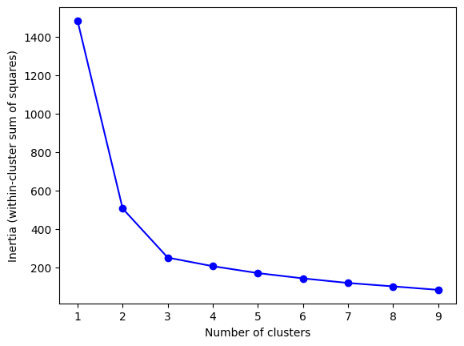

**Elbow Method**

- Plot the within-cluster sum of squares (WCSS) against the number of clusters.
- WCSS measures the compactness of the clusters.
- The idea is to identify the "elbow" point in the plot, where the rate of decrease in WCSS slows down significantly. This point represents a good balance between minimizing intra-cluster distance and avoiding overfitting.

**Silhouette Analysis**

For each observation $i$ calculate $a(i)$, the average distance from other observations in its cluster, and $b(i)$, the average distance from observations in the closest other cluster. The silhouette score for observation $i$, $s(i)$, is defined as \begin{equation} s(i) = \frac{b(i)-a(i)}{\max[a(i),b(i)]} \end{equation}

The silhouette coefficient can vary between $-1$ and $+1$: a coefficient close to $+1$ means that the instance is **well inside its own cluster and far from other clusters**, while a coefficient close to $0$ means that it is close to a cluster boundary, and finally a coefficient close to $-1$ means that the instance may have been assigned to the wrong cluster. So we have to choose the number of clusters that **maximizes the average silhouette** score across all observations

### Example 2 - Country Risk

**The Country Risk Dataset (J. C. Hull, 2019, Chapter 2)**

Consider the problem of understanding the risk of countries for foreign investment. Among the features that can be used for this are:

- GDP growth rate (IMF)
- Corruption index (Transparency international)
- Peace index (Institute for Economics and Peace)
- Legal Risk Index (Property Rights Association)

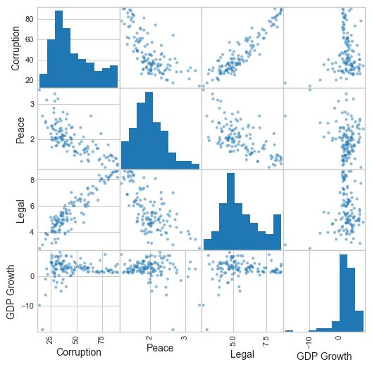

### Limits of K-Means

- Despite its many merits, most notably being fast and scalable, K-Means is not perfect.
- As we saw, it is necessary to run the algorithm several times to avoid sub-optimal solutions, plus you need to specify the number of clusters, which can be quite a hassle.
- Moreover, K-Means does not behave very well when the clusters have varying sizes, different densities, or non-spherical shapes.

[figure not shown]

*Source: Géron (see References and Credits Section)*

## Hierarchical Clustering

**Definition**

- Hierarchical clustering algorithms are a family of algorithms used in machine learning for grouping data points into a hierarchy of clusters.
- These algorithms build a hierarchy of clusters either by starting with individual data points and successively merging them (**agglomerative approach**) or by beginning with the entire data set and successively dividing it into smaller clusters (**divisive approach**).
- The process creates a tree-like structure known as a **dendrogram**, which illustrates how individual elements are grouped into clusters.

**Key Characteristics of Hierarchical Clustering:**

1. **Agglomerative Approach**: This is the more commonly used method in hierarchical clustering. It starts by treating each data point as a single cluster. Then, iteratively, the closest pairs of clusters are merged, creating a hierarchy from the bottom up. The process continues until all points are merged into a single cluster, or a stopping criterion is met.
2. **Divisive Approach**: In contrast, divisive methods start with the entire dataset as one large cluster and then partition it into smaller clusters. This partitioning continues recursively, leading to finer and more specific clusters, until each data point is in its own cluster or a stopping criterion is reached.

[figure not shown]

*Source: https://i1.wp.com/rposts.com/wpcontent/uploads/2017/12/Agnes.png*

**Creating a Dendrogram**

Both approaches produce a dendrogram, a tree-like diagram that records the sequences of merges or splits. The height at which two clusters are joined in the dendrogram represents the distance between these clusters, providing valuable insights into the data structure.

**Distance Metrics and Linkage Criteria**

- The choice of distance metric (e.g., Euclidean, Manhattan) and linkage criterion (e.g., single linkage, complete linkage, average linkage, see below for a description) plays a crucial role in hierarchical clustering. These determine how the similarity between clusters is calculated and directly influence the clustering outcome.
- The linkage criterion determines the distance between sets of observations as a function of the pairwise distances between observations. It's a rule used to decide when to combine two clusters into a single cluster as the algorithm progresses either bottom-up (agglomerative) or top-down (divisive). Here are the most common types of linkage criteria:
1. **Single Linkage (Nearest Point Algorithm)**: The distance between two clusters is defined as the shortest distance between any single member of one cluster and any single member of the other cluster. This can result in a chaining effect, where clusters end up being long and straggly.

[figure not shown]

*Source: https://www.saedsayad.com/images/Clustering_single.png*

2. **Complete Linkage (Farthest Point Algorithm)**: The distance between two clusters is defined as the longest distance between any single member of one cluster and any single member of the other cluster. This tends to produce more compact, tightly bound clusters.

[figure not shown]

*Source:- https://www.saedsayad.com/images/Clustering_complete.png*

3. **Average Linkage (Average of Pairs)**: The distance between two clusters is computed as the average distance between all pairs of individuals in the two clusters. This creates a balance between the single and complete linkage criteria and is less affected by outliers than either.

[figure not shown]

*Source:- https://www.saedsayad.com/images/Clustering_average.png*

**Other Linkage Methods**

- **Centroid Linkage (Minimum Centroid Distance)**: The distance between two clusters is the distance between their centroids - that is, the mean point of each cluster. Clusters are merged based on the proximity of their centroids.
- **Ward’s Method (Minimum Variance Method)**: This approach aims to minimize the total within-cluster variance. At each step, the pair of clusters with the minimum between-cluster distance are merged. This method tends to create clusters of roughly equal size, which is useful in some contexts but not all.

The choice of linkage criterion can significantly affect the shape and the size of the clusters formed by hierarchical clustering, and it should be chosen based on the nature of the data and the desired clustering resolution.

### A Simple Example with Synthetic Data

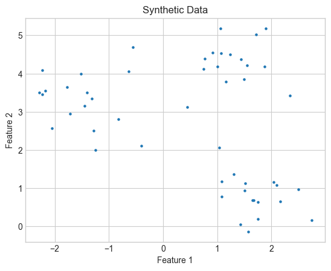

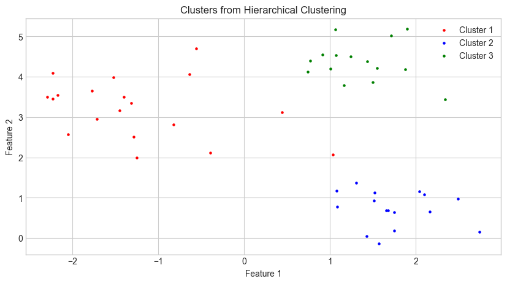

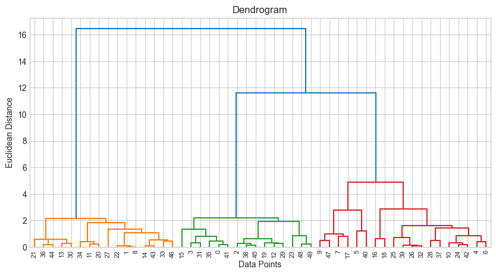

**Advantages of Hierarchical Clustering:**

- **No Need to Specify Number of Clusters**: Unlike K-means, hierarchical clustering does not require the user to specify the number of clusters beforehand.
- **Flexibility and Richness**: The hierarchical structure offers a more nuanced view of the data, as it captures relationships at different levels.
- **Easy to Interpret**: The dendrogram provides an intuitive and visual representation of the clustering process and data structure.

**Challenges and Limitations:**

- **Computational Complexity**: Especially for agglomerative methods, the computational complexity can be quite high for large datasets, making them less scalable than other clustering methods like K-means.
- **Sensitivity to Noise and Outliers**: Hierarchical clustering can be sensitive to noise and outliers, which can lead to misinterpretations of the data structure.
- **Irreversibility**: Once a step (merge or split) is done, it cannot be undone in later iterations, which might lead to suboptimal clustering in some cases.

## DBSCAN

**Definition**

DBSCAN, which stands for **Density-Based Spatial Clustering of Applications with Noise**, is a popular clustering algorithm used in machine learning. It is a density-based clustering algorithm because it forms clusters based on dense regions of points. Here's an overview of how DBSCAN works:

1. **Core Points**: DBSCAN begins by identifying "core points," which are points that have at least a minimum number of other points (MinPts) within a certain radius (ε, epsilon). This radius can be thought of as a circle (or sphere in higher dimensions) drawn around each data point.
2. **Clusters**: Clusters are formed by connecting core points that are within ε distance of each other. If a core point is within this distance of another core point, they are part of the same cluster. This process continues until all core points are connected to clusters.
3. **Border Points**: There are also "border points," which are not core points (since they have fewer than MinPts within their ε neighborhood) but are within the ε radius of a core point and hence are included in the cluster.
4. **Noise**: Any point that is not a core point or a border point is considered "noise" and is not included in any cluster. This makes DBSCAN particularly good at handling outliers.

[figure not shown]

In this diagram, minPts = 4. Point A and the other red points are core points, because the area surrounding these points in an ε radius contain at least 4 points (including the point itself). Because they are all reachable from one another, they form a single cluster. Points B and C are not core points, but are reachable from A (via other core points) and thus belong to the cluster as well. Point N is a noise point that is neither a core point nor directly-reachable.

*Source:- Wikipedia*

DBSCAN has several advantages:

- It **does not require specifying the number of clusters in advance**, unlike K-means.
- It can find **arbitrarily shaped** clusters.
- It has a notion of noise and is thus robust to outliers.

However, DBSCAN also has its drawbacks:

- It can struggle with datasets where clusters vary widely in density.
- Choosing the right ε and MinPts can be difficult without domain knowledge or some parameter tuning strategy.

In conclusion, DBSCAN is a powerful clustering algorithm when you have spatial data with clusters of similar density and you need an algorithm that can handle noise and outliers.

### Use DBSCAN class in Scikit-Learn

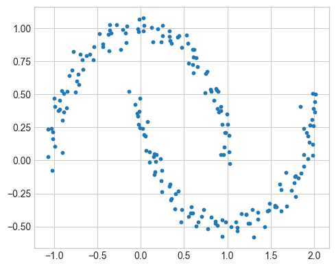

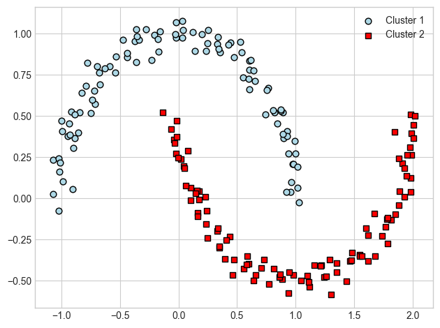

## References and Credits

[1] - Géron A. - "Hands On Machine Learning with Scikit-Learn Keras and Tensorflow", 2nd Ed, O'Reilly

[2] - Irani J. et al. - ["Clustering Techniques and the Similarity Measures used in Clustering: A Survey"](https://www.ijcaonline.org/research/volume134/number7/irani-2016-ijca-907841.pdf), *International Journal of Computer Applications (0975 – 8887), Volume 134 – No.7, January 2016.*

[3] - Hull J. C. - "Machine Learning in Business: An Introduction to the World of Data Science", Amazon, 2019.

Other Usefull link:

[Equivalent of Elbow Method](https://stackoverflow.com/questions/41540751/sklearn-kmeans-equivalent-of-elbow-method)